# Illustration of the `permDep` function

Sy Han (Steven) Chiou

2019-08-14

## Objective

In this vignette, we demonstrate the usage of the `permDep` function.

## Generating truncated data

We define the following functions to generate survival data with dependent left-truncation.

In the first setting, we generate the survival time from a Weibull distribution with shape parameter 3 and scale parameter 8.5 and generate the truncation time from an exponential with mean 5. The dependence between the survival time and the truncation time is controlled by a normal copula from the `copula` package with a pre-specified pre-truncation unconditional Kendall’s tau (`tau`).

```r
> library(copula)
> simDat1 <- function(n, tau) {
+     k <- 1
+     tt <- xx <- rep(-1, n)
+     kt <- iTau(normalCopula(), tau)
+     cp <- normalCopula(kt, dim = 2)
+     dist <- mvdc(cp, c("exp", "weibull"), list(list(rate = 0.2), list(shape = 3, scale = 8.5)))
+     while(k <= n){
+         dat <- rMvdc(1, dist)
+         tt[k] <- dat[1]
+         xx[k] <- dat[2]
+         if(tt[k] <= xx[k]) k = k + 1
+     }
+     data.frame(Trun = tt, Time = xx)
+ }
```

The `simDat1` funciton generates monotone dependence model and is used in Chiou et al. (2018) in the absence of censoring. The following scatterplots confirms the monotonic dependence.

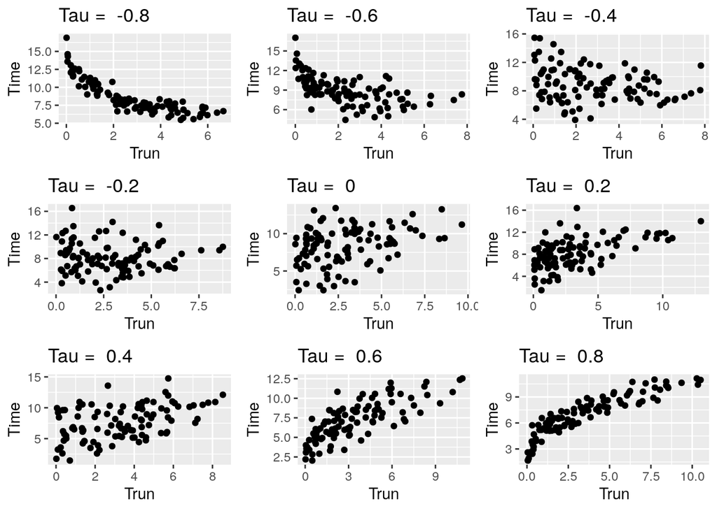

```r
> library(ggplot2)
> library(gridExtra)
> set.seed(123)
> tmp <- lapply(-4:4/5, function(x)
+   qplot(Trun, Time, data = simDat1(100, x), main = paste("Tau = ", x)))
> do.call("grid.arrange", c(tmp, ncol = 3))
```

```r
> simDat2 <- function(n, tau) {
+     k <- 1
+     tt <- xx <- rep(-1, n)
+     kt <- iTau(normalCopula(), tau)
+     cp <- normalCopula(kt, dim = 2)
+     dist <- mvdc(cp, c("unif", "weibull"),
+                  list(list(min = 0, max = 1), list(shape = 1, scale = 4)))
+     while(k <= n){
+         tmp <- rMvdc(1, dist)
+         if (k <= n/2) tt[k] <- tmp[1]
+         if (k > n/2) tt[k] <- 2 - tmp[1]
+         xx[k] <- tmp[2]
+         if(tt[k] <= xx[k]) k = k + 1
+     }
+     dat <- data.frame(Trun = tt, Time = xx)
+     dat
+ }
```

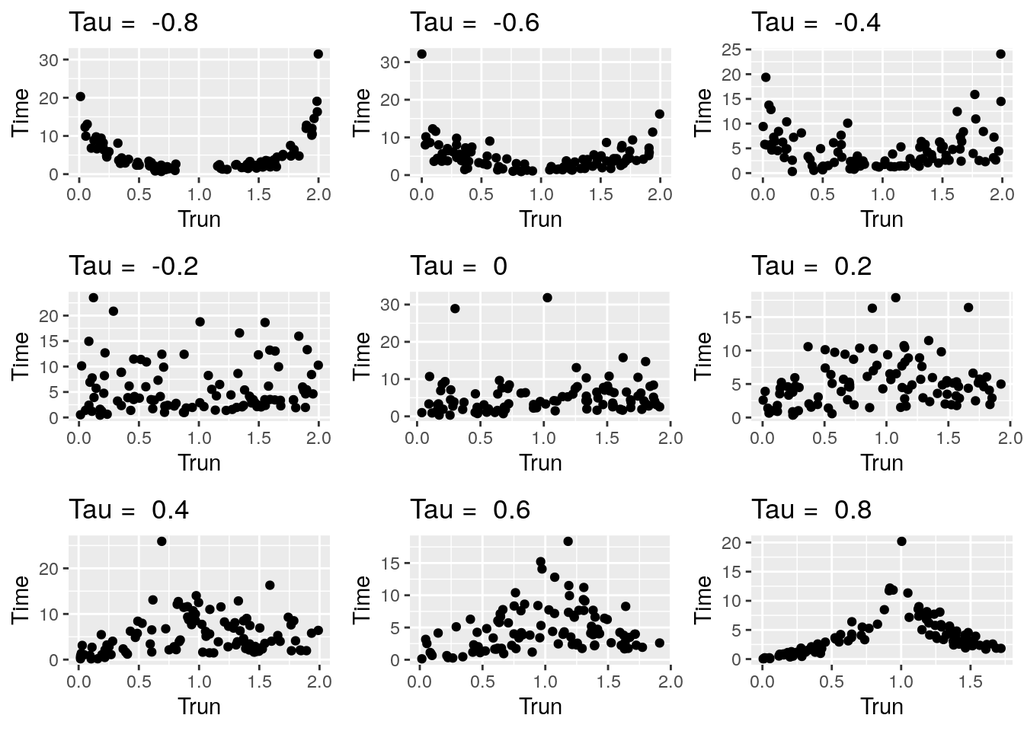

```r
> set.seed(123)
> tmp <- lapply(-4:4/5, function(x)
+   qplot(Trun, Time, data = simDat2(100, x), main = paste("Tau = ", x)))
> do.call("grid.arrange", c(tmp, ncol = 3))
```

## The `permDep` function

The arguments of `permDep` are as follow

```r
> args(permDep)
function (trun, obs, permSize, cens, sampling = c("conditional",
    "unconditional", "is.conditional", "is.unconditional"), kendallOnly = FALSE,
    minp1Only = FALSE, minp2Only = FALSE, nc = ceiling(detectCores()/2),
    seed = NULL, minp.eps = NULL, plot.int = FALSE, anim_name = NULL)
NULL
```

The arguments are

- `trun` is the left truncation time
- `obs` is the observed failure time; this is defined to be the minimum of the survival time and censoring time In addition, this is required to be greater than the truncation time
- `permSize` is the number of permutations
- `cens` is the status indicator; 0 = censored, 1 = event
- `sampling` is a character string specifying the sampling method used in permutation. The following are permitted.
  - `conditional` conditional permutation
  - `unconditional` unconditional permutation
  - `is.conditional` importance sampling version of the conditional permutation (under development)
  - `is.unconditional` importance sampling version of the unconditional permutation (under development)
- `kendallOnly` is a logical value indicating whether to use the conditional Kendall’s tau as the only test statistics
- `minp1Only` is a logical value indicating whether to use the minp1 test as the only test statistics
- `minp2Only` is a logical value indicating whether to use the minp2 test as the only test statistics
  - The default is to use all three test statistics (conditional Kendall’s tau, minp1, and minp2)
- `nc` is the number of cores used in the permutation test. When `nc > 1`, permutation is carried out with parallel computing methods. The default is to use half of the available number of CPU cores on the current host.
- `seed` is an optional vector containing random seeds to be used to generate permutation samples. Random seeds will be used when left unspecified.
- `minp.eps` is an optional value indicating the width of the intervals used in minp2 procedure. The following are permitted.
  - *a single numerical number* sets the common width for all intervals
  - *a numerical vector* uses user specified width for the intervals. The length of the vector needs to be a sub-multiple or multiple of the number of uncensored events.
  - *a character string* uses the pre-implemented algorithm to calculate the width of the intervals. This option can be either “in” or “out”, which require the minimum number of uncensored events inside or outside of each interval, respectively.
  - `NULL` uses the automatic selection algorithm outlined in Chiou et al. (2018)
- `plot.int` is a logical value indicating whether to plot the intervals when applying the minp tests. This is more useful when only one of `minp1Only` and `minp2Only` is `TRUE`.

We will illustrate the usage of `permDep` with simulated data generated from `simDat1` and `simDat2`.

## Permutation test

We first use a small sample size example to demonstrate the different features.

```r
> set.seed(123)
> dat <- simDat1(30, .9) ## highly correlated data
```

### With or without parallel computing

Note that the computation time depends on the machine setting in the current host.

```r
> parallel::detectCores()
[1] 8
> set.seed(123);system.time(f1 <- permDep(dat$Trun, dat$Time, 500, nc = 1))
   user  system elapsed
 21.385   0.002  21.300
> set.seed(123);system.time(f2 <- permDep(dat$Trun, dat$Time, 500, nc = parallel::detectCores()))
   user  system elapsed
  0.103   0.039  12.457
> identical(f1, f2)
[1] TRUE
> f1

 Hypothesis test of quasi-independence based on conditional Kendall's tau statistics
 Conditional permutation with size =  500
 p-value = 0.0020

 Hypothesis test of quasi-independence based on minp1 statistics
 Conditional permutation size =  500
 p-value = 0.0020

 Hypothesis test of quasi-independence based on minp2 statistics
 Conditional permutation size =  500
 p-value = 0.0060
```

Computation time is faster with parallel computation, e.g., `f2`, but using 8 does not make the program run 8 faster.

### Different `minp.eps` options

```r
> permDep(dat$Trun, dat$Time, 500, minp2Only = TRUE)$p.valueMinp2
[1] 0.005988024
> permDep(dat$Trun, dat$Time, 500, minp2Only = TRUE, minp.eps = 0.5)$p.valueMinp2
[1] 0.01197605
> permDep(dat$Trun, dat$Time, 500, minp2Only = TRUE, minp.eps = "in")$p.valueMinp2
[1] 0.001996008
> permDep(dat$Trun, dat$Time, 500, minp2Only = TRUE, minp.eps = "out")$p.valueMinp2
[1] 0.001996008
```

The performance of the minp2 test depends on the specification of the interval width (e.g., `minp.esp`), however, the resulting $p$-values from the above example are significant at $\alpha = 0.05$.

## Track intervals from minp tests

Enabling `plot.int` allows users to visualize the intervals used in computing the log-rank statistics when applying the minp1 and the minp2 tests on the observed data.

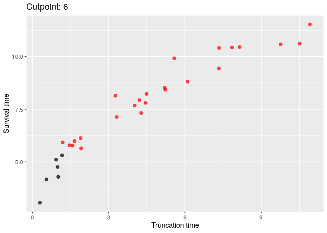

```r
> permDep(dat$Trun, dat$Time, 500, minp1Only = TRUE,
+         plot.int = TRUE, anim_name = "vig-minp1")

 Hypothesis test of quasi-independence based on minp1 statistics
 Conditional permutation size =  500
 p-value = 0.0020
```

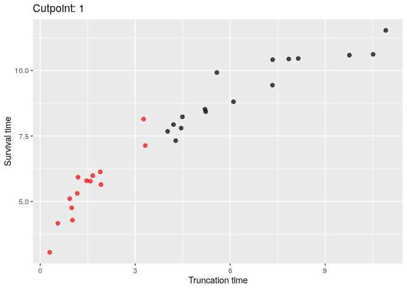

```r
> permDep(dat$Trun, dat$Time, 500, minp2Only = TRUE,
+         plot.int = TRUE, anim_name = "vig-minp2")

 Hypothesis test of quasi-independence based on minp2 statistics
 Conditional permutation size =  500
 p-value = 0.0080
```

We use `simDat2` to generate truncated data with non-monotone dependence. This scenario would emphasize the usefulness of the minp2 test.

```r
> set.seed(123)
> dat <- simDat2(100, -.9) ## highly correlated data
```

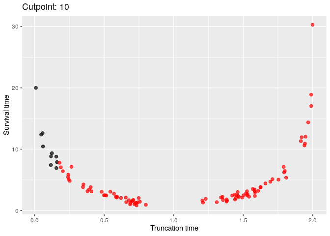

```r
> permDep(dat$Trun, dat$Time, 500, minp1Only = TRUE,
+         plot.int = TRUE, anim_name = "vig-minp1-non-monotone")

 Hypothesis test of quasi-independence based on minp1 statistics
 Conditional permutation size =  500
 p-value = 0.0080
```

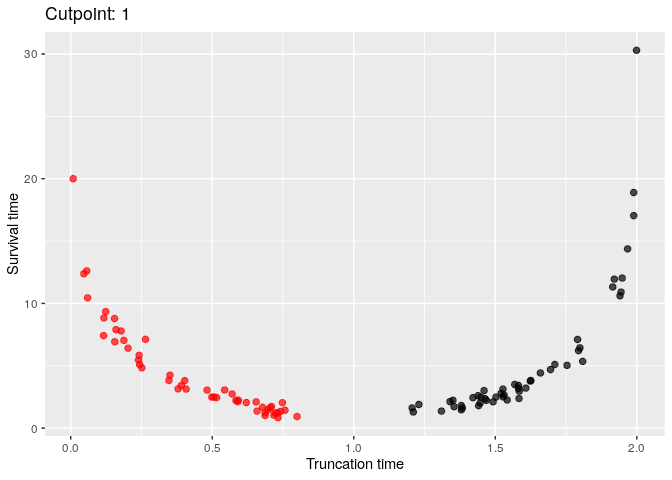

```r
> permDep(dat$Trun, dat$Time, 500, minp2Only = TRUE,
+         plot.int = TRUE, anim_name = "vig-minp2-non-monotone")

 Hypothesis test of quasi-independence based on minp2 statistics
 Conditional permutation size =  500
 p-value = 0.0080
```

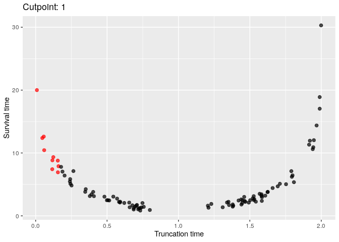

```r
> permDep(dat$Trun, dat$Time, 500, minp2Only = TRUE, minp.eps = "out",
+         plot.int = TRUE, anim_name = "vig-minp2-2")

 Hypothesis test of quasi-independence based on minp2 statistics
 Conditional permutation size =  500
 p-value = 0.0020
```

## Reference

Chiou, Sy Han, Jing Qian, Elizabeth Mormino, Rebecca A Betensky, Lifestyle Flagship Study of Aging, Harvard Aging Brain Study, Alzheimer’s Disease Neuroimaging Initiative, and others. 2018. “Permutation Tests for General Dependent Truncation.” *Computational Statistics & Data Analysis* 128. Elsevier: 308–24.